# Convolutional Neural Networks (CNNs) tutorial for [CS-772 2025](https://www.cse.iitb.ac.in/~cs772/)

Author: [Jimut Bahan Pal](https://jimut123.github.io/)

## Multiclass Image Segmentation - Segmenting wild plants

The original augmented dataset can be downloaded from [here](https://figshare.com/articles/dataset/Multiclass_Weeds_Dataset_for_Image_Segmentation/22643434?file=40195219).

A mirror copy of the dataset can also be found [here](https://drive.google.com/file/d/1Ihjzt59qzBmI6JbBgJZpZyTg1wjZvKnE/view?usp=sharing).

### Install the necessary libraries

```python
! pip install -q gdown
! pip install -q colorama # for color-based texts
! pip install -q torchviz # for visualizing graphs
! pip install -q torchview # for visualizing graphs
! pip install -q graphviz # for visualizing graphs
! pip install -q torchsummary # for finding the number of parameters of a model
```

```python
# delete dataset if already present
! rm -rf dataset.zip
```

### Download the dataset from Google Drive

```python
! gdown --id 1Ihjzt59qzBmI6JbBgJZpZyTg1wjZvKnE -O dataset.zip
```

```python
! unzip -qq dataset.zip
```

### Check the number of images present in the whole dataset

```python
! ls weed_augmented/images/* | wc
```

```
   7872    7872  259776
```

### Imports

```python
# General imports
import os
import cv2
import glob
import numpy as np
import random
from tqdm import tqdm
from pathlib import Path
from colorama import Fore, Style
from collections import Counter, defaultdict

# Model based imports
import torch
import torch.nn as nn
import torch.nn.functional as F
import torch.optim as optim
from torch.utils.data import Dataset, DataLoader

# Viz-based imports
from torchsummary import summary
from torchview import draw_graph
import graphviz
graphviz.set_jupyter_format('png')
import seaborn as sns
import matplotlib.pyplot as plt

# Set device
device = torch.device('cuda' if torch.cuda.is_available() else 'cpu')
print(f"Using device: {device}")


SEED = 42
random.seed(SEED)
np.random.seed(SEED)
```

```
Using device: cuda
```

### This dataset contains three pixel classes; here, we examine the percentage of pixels belonging to each class.

```python
def analyze_3class_masks(mask_folder="./weed_augmented/masks/"):
    """
    Fast analysis for 3-class segmentation masks with specific RGB values.
    """
    # Define the 3 classes
    classes = {
        'background': np.array([0, 0, 0]),      # Black
        'class_1': np.array([0, 128, 0]),       # Green
        'class_2': np.array([0, 0, 128])        # Blue
    }

    # Initialize counters
    counts = {name: 0 for name in classes.keys()}
    total_pixels = 0

    # Get all mask files
    mask_files = glob.glob(f"{mask_folder}*.png")
    print(f"Processing {len(mask_files)} mask files...")

    # Process each mask
    for mask_file in tqdm(mask_files, desc="Analyzing masks"):
        # Read mask (BGR format)
        mask_rgb = cv2.imread(mask_file)
        if mask_rgb is None:
            continue

        # Convert BGR to RGB
        # mask_rgb = cv2.cvtColor(mask_bgr, cv2.COLOR_BGR2RGB)
        h, w = mask_rgb.shape[:2]
        total_pixels += h * w

        # Count pixels for each class using vectorized operations
        for class_name, class_color in classes.items():
            # Create boolean mask for this class
            matches = np.all(mask_rgb == class_color, axis=2)
            counts[class_name] += np.sum(matches)

    # Calculate percentages
    print(f"\n{'Class':<12} {'Pixels':<12} {'Percentage'}")
    print("-" * 35)

    for class_name, pixel_count in counts.items():
        percentage = (pixel_count / total_pixels) * 100 if total_pixels > 0 else 0
        print(f"{class_name:<12} {pixel_count:<12,} {percentage:.2f}%")

    print(f"\nTotal pixels: {total_pixels:,}")
    print(f"Files processed: {len(mask_files)}")

    return counts, total_pixels


analyze_3class_masks()
```

```
Processing 7872 mask files...
```

```
Class        Pixels       Percentage
-----------------------------------
background   1,662,369,971 80.56%
class_1      193,860,104  9.39%
class_2      206,718,645  10.02%

Total pixels: 2,063,597,568
Files processed: 7872
```

```
({'background': np.int64(1662369971),
  'class_1': np.int64(193860104),
  'class_2': np.int64(206718645)},
 2063597568)
```

### Creating the train-val-test split, with 60% of the dataset for training, 10% of the dataset for validation and 30% of the dataset for testing; also resizing the images to 256x256 size before creating the dataset. Store the image masks pairs in the respective folders, i.e., `train_images, train_masks, val_images, val_masks, test_images, and test_masks.`

```python
# Configuration
source_folder = 'weed_augmented'
output_folder = '.'
# use a seed of 42 for reproducibility
# random.seed(42)


# Create directories
dirs = ['train_images', 'train_masks', 'val_images', 'val_masks', 'test_images', 'test_masks']
for dir_name in dirs:
    os.makedirs(os.path.join(output_folder, dir_name), exist_ok=True)

# Get matching image-mask pairs
images_path = os.path.join(source_folder, 'images')
masks_path = os.path.join(source_folder, 'masks')

image_files = [f for f in os.listdir(images_path) if f.lower().endswith('.jpg')]
pairs = []

for img_file in image_files:
    mask_file = img_file.replace('.jpg', '.png')
    if os.path.exists(os.path.join(masks_path, mask_file)):
        pairs.append((img_file, mask_file))

print(f"Found {len(pairs)} matching image-mask pairs")

# Shuffle and split
random.shuffle(pairs)
n_total = len(pairs)
n_train = int(n_total * 0.6)
n_val = int(n_total * 0.1)

train_pairs = pairs[:n_train]
val_pairs = pairs[n_train:n_train + n_val]
test_pairs = pairs[n_train + n_val:]

print(f"Split: Train={len(train_pairs)}, Val={len(val_pairs)}, Test={len(test_pairs)}")


# Process and resize images
target_size = (256, 256)

for pairs_list, split_name in [(train_pairs, 'train'), (val_pairs, 'val'), (test_pairs, 'test')]:
    for img_file, mask_file_name in tqdm(pairs_list):
        # Load and resize image
        img = cv2.imread(os.path.join(images_path, img_file))
        img_resized = cv2.resize(img, target_size, interpolation=cv2.INTER_LINEAR)

        # Load and resize mask
        mask = cv2.imread(os.path.join(masks_path, mask_file_name))
        mask_resized = cv2.resize(mask, target_size, interpolation=cv2.INTER_NEAREST)

        # Save resized images
        cv2.imwrite(os.path.join(output_folder, f'{split_name}_images', mask_file_name), img_resized)
        cv2.imwrite(os.path.join(output_folder, f'{split_name}_masks', mask_file_name), mask_resized)
```

```
Found 7872 matching image-mask pairs
Split: Train=4723, Val=787, Test=2362
```

### Creating overlays of the masks with the images, and showing first 5 samples from each of the train, validation and test splits

```
Most common mask colors (RGB):
  (np.uint8(0), np.uint8(0), np.uint8(0))
  (np.uint8(128), np.uint8(0), np.uint8(0))
  (np.uint8(0), np.uint8(128), np.uint8(0))
  (np.uint8(1), np.uint8(0), np.uint8(0))
  (np.uint8(2), np.uint8(0), np.uint8(0))
```

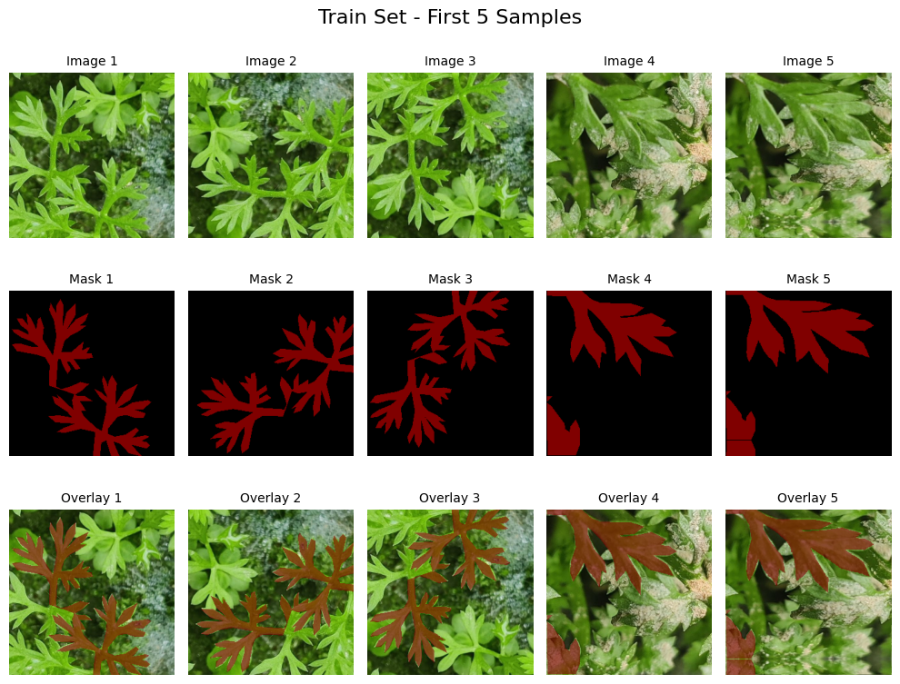

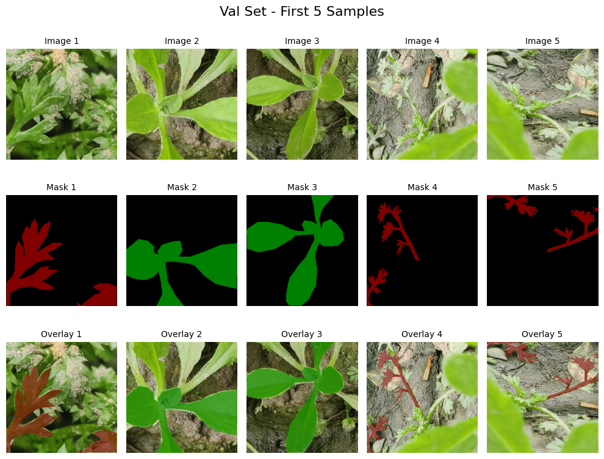

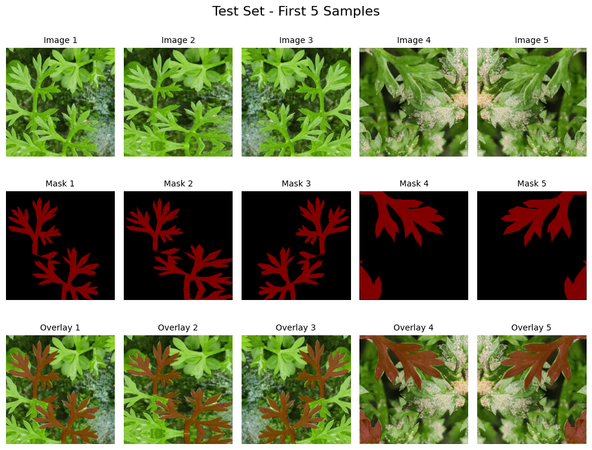

```
Dataset organized in '.' folder
```

```python
# Analyze mask colors
mask_folder = os.path.join(output_folder, 'train_masks')
mask_files = [f for f in os.listdir(mask_folder) if f.lower().endswith('.png')]
sample_files = random.sample(mask_files, min(20, len(mask_files)))

all_colors = []
for filename in sample_files:
    mask = cv2.imread(os.path.join(mask_folder, filename))
    mask_rgb = cv2.cvtColor(mask, cv2.COLOR_BGR2RGB)
    unique_colors = np.unique(mask_rgb.reshape(-1, 3), axis=0)
    all_colors.extend([tuple(color) for color in unique_colors])

color_counts = Counter(all_colors)
class_colors = [color for color, _ in color_counts.most_common(10)]

print("Most common mask colors (RGB):")
for color in class_colors[:5]:
    print(f"  {color}")

# Visualize samples
def create_overlay(image, mask, colors, alpha=0.6):
    overlay = image.copy()
    mask_rgb = cv2.cvtColor(mask, cv2.COLOR_BGR2RGB)

    for color in colors:
        if color == (0, 0, 0):
            continue
        color_mask = np.all(mask_rgb == color, axis=2)
        if np.any(color_mask):
            overlay[color_mask] = (alpha * np.array(color) + (1 - alpha) * overlay[color_mask]).astype(np.uint8)
    return overlay

# Show samples for each split
for split in ['train', 'val', 'test']:
    img_folder = os.path.join(output_folder, f'{split}_images')
    mask_folder = os.path.join(output_folder, f'{split}_masks')

    img_files = sorted([f for f in os.listdir(img_folder) if f.lower().endswith('.png')])[:5]

    if not img_files:
        continue

    fig, axes = plt.subplots(3, len(img_files), figsize=(10, 8))
    fig.suptitle(f'{split.capitalize()} Set - First {len(img_files)} Samples', fontsize=16)

    for i, img_file in enumerate(img_files):
        mask_file = img_file

        img = cv2.imread(os.path.join(img_folder, img_file))
        img_rgb = cv2.cvtColor(img, cv2.COLOR_BGR2RGB)

        mask = cv2.imread(os.path.join(mask_folder, mask_file))
        mask_rgb = cv2.cvtColor(mask, cv2.COLOR_BGR2RGB)

        overlay = create_overlay(img_rgb, mask, class_colors)

        axes[0, i].imshow(img_rgb)
        axes[0, i].set_title(f'Image {i+1}', fontsize=10)
        axes[0, i].axis('off')

        axes[1, i].imshow(mask_rgb)
        axes[1, i].set_title(f'Mask {i+1}', fontsize=10)
        axes[1, i].axis('off')

        axes[2, i].imshow(overlay)
        axes[2, i].set_title(f'Overlay {i+1}', fontsize=10)
        axes[2, i].axis('off')

    plt.tight_layout()
    plt.show()

print(f"Dataset organized in '{output_folder}' folder")
```

### We use the [ResUNet++](https://arxiv.org/pdf/1911.07067) architecture for image segmentation, which is very lightweight in itself.

[figure not shown]

```python
# https://github.com/DebeshJha/ResUNetPlusPlus-with-CRF-and-TTA/blob/master/resunet%2B%2B_pytorch.py
# Note: This uses 3-channel input (in standard channel-first mode)

class Squeeze_Excitation(nn.Module):
    def __init__(self, channel, r=8):
        super().__init__()

        self.pool = nn.AdaptiveAvgPool2d(1)
        self.net = nn.Sequential(
            nn.Linear(channel, channel // r, bias=False),
            nn.ReLU(inplace=True),
            nn.Linear(channel // r, channel, bias=False),
            nn.Sigmoid(),
        )

    def forward(self, inputs):
        b, c, _, _ = inputs.shape
        x = self.pool(inputs).view(b, c)
        x = self.net(x).view(b, c, 1, 1)
        x = inputs * x
        return x

class Stem_Block(nn.Module):
    def __init__(self, in_c, out_c, stride):
        super().__init__()

        self.c1 = nn.Sequential(
            nn.Conv2d(in_c, out_c, kernel_size=3, stride=stride, padding=1),
            nn.BatchNorm2d(out_c),
            nn.ReLU(),
            nn.Conv2d(out_c, out_c, kernel_size=3, padding=1),
        )

        self.c2 = nn.Sequential(
            nn.Conv2d(in_c, out_c, kernel_size=1, stride=stride, padding=0),
            nn.BatchNorm2d(out_c),
        )

        self.attn = Squeeze_Excitation(out_c)

    def forward(self, inputs):
        x = self.c1(inputs)
        s = self.c2(inputs)
        y = self.attn(x + s)
        return y

class ResNet_Block(nn.Module):
    def __init__(self, in_c, out_c, stride):
        super().__init__()

        self.c1 = nn.Sequential(
            nn.BatchNorm2d(in_c),
            nn.ReLU(),
            nn.Conv2d(in_c, out_c, kernel_size=3, padding=1, stride=stride),
            nn.BatchNorm2d(out_c),
            nn.ReLU(),
            nn.Conv2d(out_c, out_c, kernel_size=3, padding=1)
        )

        self.c2 = nn.Sequential(
            nn.Conv2d(in_c, out_c, kernel_size=1, stride=stride, padding=0),
            nn.BatchNorm2d(out_c),
        )

        self.attn = Squeeze_Excitation(out_c)

    def forward(self, inputs):
        x = self.c1(inputs)
        s = self.c2(inputs)
        y = self.attn(x + s)
        return y

class ASPP(nn.Module):
    def __init__(self, in_c, out_c, rate=[1, 6, 12, 18]):
        super().__init__()

        self.c1 = nn.Sequential(
            nn.Conv2d(in_c, out_c, kernel_size=3, dilation=rate[0], padding=rate[0]),
            nn.BatchNorm2d(out_c)
        )

        self.c2 = nn.Sequential(
            nn.Conv2d(in_c, out_c, kernel_size=3, dilation=rate[1], padding=rate[1]),
            nn.BatchNorm2d(out_c)
        )

        self.c3 = nn.Sequential(
            nn.Conv2d(in_c, out_c, kernel_size=3, dilation=rate[2], padding=rate[2]),
            nn.BatchNorm2d(out_c)
        )

        self.c4 = nn.Sequential(
            nn.Conv2d(in_c, out_c, kernel_size=3, dilation=rate[3], padding=rate[3]),
            nn.BatchNorm2d(out_c)
        )

        self.c5 = nn.Conv2d(out_c, out_c, kernel_size=1, padding=0)


    def forward(self, inputs):
        x1 = self.c1(inputs)
        x2 = self.c2(inputs)
        x3 = self.c3(inputs)
        x4 = self.c4(inputs)
        x = x1 + x2 + x3 + x4
        y = self.c5(x)
        return y

class Attention_Block(nn.Module):
    def __init__(self, in_c):
        super().__init__()
        out_c = in_c[1]

        self.g_conv = nn.Sequential(
            nn.BatchNorm2d(in_c[0]),
            nn.ReLU(),
            nn.Conv2d(in_c[0], out_c, kernel_size=3, padding=1),
            nn.MaxPool2d((2, 2))
        )

        self.x_conv = nn.Sequential(
            nn.BatchNorm2d(in_c[1]),
            nn.ReLU(),
            nn.Conv2d(in_c[1], out_c, kernel_size=3, padding=1),
        )

        self.gc_conv = nn.Sequential(
            nn.BatchNorm2d(in_c[1]),
            nn.ReLU(),
            nn.Conv2d(out_c, out_c, kernel_size=3, padding=1),
        )

    def forward(self, g, x):
        g_pool = self.g_conv(g)
        x_conv = self.x_conv(x)
        gc_sum = g_pool + x_conv
        gc_conv = self.gc_conv(gc_sum)
        y = gc_conv * x
        return y

class Decoder_Block(nn.Module):
    def __init__(self, in_c, out_c):
        super().__init__()

        self.a1 = Attention_Block(in_c)
        self.up = nn.Upsample(scale_factor=2, mode="nearest")
        self.r1 = ResNet_Block(in_c[0]+in_c[1], out_c, stride=1)

    def forward(self, g, x):
        d = self.a1(g, x)
        d = self.up(d)
        d = torch.cat([d, g], axis=1)
        d = self.r1(d)
        return d

class ResUnetPlusPlus(nn.Module):
    def __init__(self, input_ch, n_class):
        super().__init__()

        self.num_classes = n_class

        self.c1 = Stem_Block(input_ch, 16, stride=1)
        self.c2 = ResNet_Block(16, 32, stride=2)
        self.c3 = ResNet_Block(32, 64, stride=2)
        self.c4 = ResNet_Block(64, 128, stride=2)

        self.b1 = ASPP(128, 256)

        self.d1 = Decoder_Block([64, 256], 128)
        self.d2 = Decoder_Block([32, 128], 64)
        self.d3 = Decoder_Block([16, 64], 32)

        self.aspp = ASPP(32, 16)
        self.output = nn.Conv2d(16, n_class, kernel_size=1, padding=0)

    def forward(self, inputs):
        c1 = self.c1(inputs)
        c2 = self.c2(c1)
        c3 = self.c3(c2)
        c4 = self.c4(c3)

        b1 = self.b1(c4)

        d1 = self.d1(c3, b1)
        d2 = self.d2(c2, d1)
        d3 = self.d3(c1, d2)

        output = self.aspp(d3)
        output = self.output(output)

        if self.num_classes == 1:
            output = torch.sigmoid(output)
        elif self.num_classes > 1:
            output = F.softmax(output, dim = 1)

        return output
```

```python
# check the model structure
#CALLING THE MODEL
model = ResUnetPlusPlus(input_ch=3, n_class=3)
# model = nn.DataParallel(model)
model = model.to(device)
print(model)
```

```
ResUnetPlusPlus(
  (c1): Stem_Block(
    (c1): Sequential(
      (0): Conv2d(3, 16, kernel_size=(3, 3), stride=(1, 1), padding=(1, 1))
      (1): BatchNorm2d(16, eps=1e-05, momentum=0.1, affine=True, track_running_stats=True)
      (2): ReLU()
      (3): Conv2d(16, 16, kernel_size=(3, 3), stride=(1, 1), padding=(1, 1))
    )
    (c2): Sequential(
      (0): Conv2d(3, 16, kernel_size=(1, 1), stride=(1, 1))
      (1): BatchNorm2d(16, eps=1e-05, momentum=0.1, affine=True, track_running_stats=True)
    )
    (attn): Squeeze_Excitation(
      (pool): AdaptiveAvgPool2d(output_size=1)
      (net): Sequential(
        (0): Linear(in_features=16, out_features=2, bias=False)
        (1): ReLU(inplace=True)
        (2): Linear(in_features=2, out_features=16, bias=False)
        (3): Sigmoid()
      )
    )
  )
  (c2): ResNet_Block(
    (c1): Sequential(
      (0): BatchNorm2d(16, eps=1e-05, momentum=0.1, affine=True, track_running_stats=True)
      (1): ReLU()
      (2): Conv2d(16, 32, kernel_size=(3, 3), stride=(2, 2), padding=(1, 1))
      (3): BatchNorm2d(32, eps=1e-05, momentum=0.1, affine=True, track_running_stats=True)
      (4): ReLU()
      (5): Conv2d(32, 32, kernel_size=(3, 3), stride=(1, 1), padding=(1, 1))
    )
    (c2): Sequential(
      (0): Conv2d(16, 32, kernel_size=(1, 1), stride=(2, 2))
      (1): BatchNorm2d(32, eps=1e-05, momentum=0.1, affine=True, track_running_stats=True)
    )
    (attn): Squeeze_Excitation(
      (pool): AdaptiveAvgPool2d(output_size=1)
      (net): Sequential(
        (0): Linear(in_features=32, out_features=4, bias=False)
        (1): ReLU(inplace=True)
```

[output cut: 208 more lines]

```
      (0): Conv2d(32, 16, kernel_size=(3, 3), stride=(1, 1), padding=(6, 6), dilation=(6, 6))
      (1): BatchNorm2d(16, eps=1e-05, momentum=0.1, affine=True, track_running_stats=True)
    )
    (c3): Sequential(
      (0): Conv2d(32, 16, kernel_size=(3, 3), stride=(1, 1), padding=(12, 12), dilation=(12, 12))
      (1): BatchNorm2d(16, eps=1e-05, momentum=0.1, affine=True, track_running_stats=True)
    )
    (c4): Sequential(
      (0): Conv2d(32, 16, kernel_size=(3, 3), stride=(1, 1), padding=(18, 18), dilation=(18, 18))
      (1): BatchNorm2d(16, eps=1e-05, momentum=0.1, affine=True, track_running_stats=True)
    )
    (c5): Conv2d(16, 16, kernel_size=(1, 1), stride=(1, 1))
  )
  (output): Conv2d(16, 3, kernel_size=(1, 1), stride=(1, 1))
)
```

### Check the parameters of the model

```python
# check the model parameters
# channel-first input
summary(model, input_size=(3, 256, 256))
```

```
----------------------------------------------------------------
        Layer (type)               Output Shape         Param #
================================================================
            Conv2d-1         [-1, 16, 256, 256]             448
       BatchNorm2d-2         [-1, 16, 256, 256]              32
              ReLU-3         [-1, 16, 256, 256]               0
            Conv2d-4         [-1, 16, 256, 256]           2,320
            Conv2d-5         [-1, 16, 256, 256]              64
       BatchNorm2d-6         [-1, 16, 256, 256]              32
 AdaptiveAvgPool2d-7             [-1, 16, 1, 1]               0
            Linear-8                    [-1, 2]              32
              ReLU-9                    [-1, 2]               0
           Linear-10                   [-1, 16]              32
          Sigmoid-11                   [-1, 16]               0
Squeeze_Excitation-12         [-1, 16, 256, 256]               0
       Stem_Block-13         [-1, 16, 256, 256]               0
      BatchNorm2d-14         [-1, 16, 256, 256]              32
             ReLU-15         [-1, 16, 256, 256]               0
           Conv2d-16         [-1, 32, 128, 128]           4,640
      BatchNorm2d-17         [-1, 32, 128, 128]              64
             ReLU-18         [-1, 32, 128, 128]               0
           Conv2d-19         [-1, 32, 128, 128]           9,248
           Conv2d-20         [-1, 32, 128, 128]             544
      BatchNorm2d-21         [-1, 32, 128, 128]              64
AdaptiveAvgPool2d-22             [-1, 32, 1, 1]               0
           Linear-23                    [-1, 4]             128
             ReLU-24                    [-1, 4]               0
           Linear-25                   [-1, 32]             128
          Sigmoid-26                   [-1, 32]               0
Squeeze_Excitation-27         [-1, 32, 128, 128]               0
     ResNet_Block-28         [-1, 32, 128, 128]               0
      BatchNorm2d-29         [-1, 32, 128, 128]              64
             ReLU-30         [-1, 32, 128, 128]               0
           Conv2d-31           [-1, 64, 64, 64]          18,496
      BatchNorm2d-32           [-1, 64, 64, 64]             128
             ReLU-33           [-1, 64, 64, 64]               0
           Conv2d-34           [-1, 64, 64, 64]          36,928
           Conv2d-35           [-1, 64, 64, 64]           2,112
      BatchNorm2d-36           [-1, 64, 64, 64]             128
AdaptiveAvgPool2d-37             [-1, 64, 1, 1]               0
```

[output cut: 121 more lines]

```
          Conv2d-159         [-1, 16, 256, 256]           4,624
     BatchNorm2d-160         [-1, 16, 256, 256]              32
          Conv2d-161         [-1, 16, 256, 256]             272
            ASPP-162         [-1, 16, 256, 256]               0
          Conv2d-163          [-1, 3, 256, 256]              51
================================================================
Total params: 4,063,027
Trainable params: 4,063,027
Non-trainable params: 0
----------------------------------------------------------------
Input size (MB): 0.75
Forward/backward pass size (MB): 893.51
Params size (MB): 15.50
Estimated Total Size (MB): 909.76
----------------------------------------------------------------
```

### Check the graph of the model

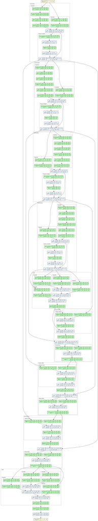

```python
# draw the computational graph of the model
model_graph1 = draw_graph(model, input_size=[(1, 3, 256, 256)],  expand_nested=True)
model_graph1.visual_graph.render(format='png')
model_graph1.visual_graph
```

### Datagenerator to query the input images and masks

```python
# Use the data generator to load the dataset
class DataGenerator(Dataset):
    def __init__(self, image_list, masks_folder, num_classes=3):
        self.files = image_list
        self.masks_folder = masks_folder
        self.num_classes = num_classes

    # NUMBER OF FILES IN THE DATASET
    def __len__(self):
        return len(self.files)

    # GETTING SINGLE PAIR OF DATA
    def __getitem__(self, idx):
        file_name = self.files[idx].split('/')[-1]
        file_name = file_name[:-4]

        mask_name = './{}/'.format(self.masks_folder) + file_name + '.png'

        img = cv2.imread(self.files[idx], cv2.IMREAD_UNCHANGED)
        if len(img.shape) == 2:
            img = cv2.merge((img, img, img))

        # Read mask as 3-channel for multi-class
        mask = cv2.imread(mask_name, cv2.IMREAD_COLOR)  # Read as BGR
        mask = cv2.cvtColor(mask, cv2.COLOR_BGR2RGB)     # Convert to RGB

        # Convert RGB mask to class indices (0, 1, 2)
        # Assuming: Black (0,0,0) = background(0), Red-ish = class-1(1), Green-ish = class-2(2)
        mask_class = np.zeros((mask.shape[0], mask.shape[1]), dtype=np.long)

        # Define color thresholds for each class
        # Background: mostly black/dark
        background_mask = (mask.sum(axis=2) < 50)

        # Class 1: red-ish (R > G and R > B)
        class1_mask = (mask[:,:,0] > mask[:,:,1]) & (mask[:,:,0] > mask[:,:,2]) & (mask[:,:,0] > 50)

        # Class 2: green-ish (G > R and G > B)
        class2_mask = (mask[:,:,1] > mask[:,:,0]) & (mask[:,:,1] > mask[:,:,2]) & (mask[:,:,1] > 50)

        mask_class[background_mask] = 0
        mask_class[class1_mask] = 1
        mask_class[class2_mask] = 2

        # Transpose image
        img_transpose = np.transpose(img, (2, 0, 1))

        # Normalize image to [0, 1]
        img_normalized = img_transpose / 255.0

        return torch.FloatTensor(img_normalized), torch.LongTensor(mask_class), str(file_name)


def load_data(image_list, masks_folder, batch_size=2, num_workers=10, shuffle=True, num_classes=3):
    dataset = DataGenerator(image_list, masks_folder=masks_folder, num_classes=num_classes)
    data_loader = DataLoader(dataset, batch_size=batch_size, num_workers=num_workers, shuffle=shuffle)
    return data_loader
```

### Define the Dice-coefficient, Intersection over union metrics and the Categorical Cross-Entropy Loss function

```python
# Dice coefficient calculation for multi-class with class indices
def dice_coefficient(pred, target, num_classes, smooth=1e-6):
    """
    Calculate dice coefficient for multi-class segmentation
    pred: predicted probabilities [B, C, H, W] (after softmax)
    target: ground truth class indices [B, H, W]
    """
    dice_scores = []

    # Convert predictions to class predictions
    pred_classes = torch.argmax(pred, dim=1)  # [B, H, W]

    for class_idx in range(num_classes):
        pred_class = (pred_classes == class_idx).float()
        target_class = (target == class_idx).float()

        intersection = (pred_class * target_class).sum(dim=(1, 2))
        union = pred_class.sum(dim=(1, 2)) + target_class.sum(dim=(1, 2))

        dice = (2. * intersection + smooth) / (union + smooth)
        dice_scores.append(dice.mean())

    return torch.stack(dice_scores), torch.stack(dice_scores).mean()


# IoU calculation for multi-class with class indices
def iou_coefficient(pred, target, num_classes, smooth=1e-6):
    """
    Calculate IoU for multi-class segmentation
    pred: predicted probabilities [B, C, H, W] (after softmax)
    target: ground truth class indices [B, H, W]
    """
    iou_scores = []

    # Convert predictions to class predictions
    pred_classes = torch.argmax(pred, dim=1)  # [B, H, W]

    for class_idx in range(num_classes):
        pred_class = (pred_classes == class_idx).float()
        target_class = (target == class_idx).float()

        intersection = (pred_class * target_class).sum(dim=(1, 2))
        union = pred_class.sum(dim=(1, 2)) + target_class.sum(dim=(1, 2)) - intersection

        iou = (intersection + smooth) / (union + smooth)
        iou_scores.append(iou.mean())

    return torch.stack(iou_scores), torch.stack(iou_scores).mean()


# Categorical Cross Entropy Loss with optional class weights
class CategoryCrossEntropyLoss(nn.Module):
    def __init__(self, weight=None):
        super(CategoryCrossEntropyLoss, self).__init__()
        self.criterion = nn.CrossEntropyLoss(weight=weight)

    def forward(self, pred, target):
        """
        pred: [B, C, H, W] - raw logits from model
        target: [B, H, W] - class indices
        """
        return self.criterion(pred, target)
```

### We have three classes, with 3 colors, here, we define the overlay code to be used in future

```python
# Create color map for visualization
def create_color_map():
    """Create color map for 3 classes: background, class-1, class-2"""
    color_map = np.array([
        [0, 0, 0],       # Background - Black
        [0, 0, 128],     # Class 1 - dark Red
        [0, 128, 0],     # Class 2 - dark Green
    ], dtype=np.uint8)
    return color_map


def apply_color_map(mask, color_map):
    """Apply color map to single channel mask"""
    h, w = mask.shape
    colored_mask = np.zeros((h, w, 3), dtype=np.uint8)
    for class_idx, color in enumerate(color_map):
        colored_mask[mask == class_idx] = color
    return colored_mask


def create_overlay(image, mask, alpha=0.6):
    """Create overlay of image and colored mask"""
    if len(image.shape) == 3 and image.shape[2] == 3:
        # Image is already RGB
        overlay = cv2.addWeighted(image.astype(np.uint8), 1-alpha, mask.astype(np.uint8), alpha, 0)
    else:
        # Convert grayscale to RGB if needed
        if len(image.shape) == 2:
            image = cv2.cvtColor(image, cv2.COLOR_GRAY2RGB)
        overlay = cv2.addWeighted(image.astype(np.uint8), 1-alpha, mask.astype(np.uint8), alpha, 0)
    return overlay
```

### Define the function for loading the images by reading it one by one

```python
# sanity check
def get_image_address(image_data_folder, subfolder_name):
    total_imgs = glob.glob(image_data_folder+subfolder_name+"/*.png")
    error_counter = 0
    TOTAL_COUNT = len(total_imgs)
    image_address_list = []
    for image_name in total_imgs:
        try:
            img = cv2.imread(image_name, cv2.IMREAD_UNCHANGED)
            x = img.shape
            image_address_list.append(image_name)
        except:
            print("Image not found : ",image_name)
            error_counter+=1
    print("Number of Files not found : ", error_counter)
    print("Total Number of Files found : ", len(image_address_list))
    return image_address_list
```

```python
# save checkpoint in pytorch
def save_ckp(checkpoint, checkpoint_path, save_after_epochs):
    if checkpoint['epoch'] % save_after_epochs == 0:
        torch.save(checkpoint, checkpoint_path)


# load checkpoint in pytorch
def load_ckp(checkpoint_path, model, model_opt):
    checkpoint = torch.load(checkpoint_path)
    model.load_state_dict(checkpoint['state_dict'])
    model_opt.load_state_dict(checkpoint['optimizer'])
    return model, model_opt, checkpoint['epoch']
```

### Here, define the function for training the model, some of the core components of this section are:

- `model.train()` -> sets the model to update the weights (training mode)
- `optimizer.zero_grad()` -> clear the gradients from the previous pass of the computational graph
- Loss computation in the model using predicted masks and ground truth masks
- `loss.backward()` -> do the backward pass
- `optimizer.step()` -> update the weights

### The `train` and `val` functions save the training and validation metrics (i.e., average Dice and IoU of the training and validation dataset) as the training progresses.

```python
def train_epoch(train_loader, model, optimizer, epoch, hist_folder_name, num_classes=3):
    print("\n\n---------------------------------------------------------------------------------------------------------------\n")

    progress_bar = tqdm(enumerate(train_loader))
    total_loss = 0.0
    total_dice = 0.0
    total_iou = 0.0

    model.train()

    # Initialize loss function with class weights (optional - adjust based on your class imbalance)
    class_weights = torch.FloatTensor([0.5, 1.0, 1.0]).to(device)  # Less weight for background
    criterion = CategoryCrossEntropyLoss(weight=class_weights)

    for step, (inp__, gt__, file_name) in progress_bar:
        #TRANSFERRING DATA TO DEVICE
        inp__ = inp__.to(device)
        gt__ = gt__.to(device)

        # clear the gradient
        optimizer.zero_grad()

        #GETTING THE PREDICTED IMAGE (raw logits)
        pred_logits = model.forward(inp__)

        # Apply softmax for probability calculation (for metrics only)
        pred_probs = torch.softmax(pred_logits, dim=1)

        #CALCULATING LOSS (using raw logits)
        loss = criterion(pred_logits, gt__)

        #LOSS TAKEN INTO CONSIDERATION
        total_loss += loss.item()

        # Calculate metrics using probabilities
        with torch.no_grad():
            dice_per_class, mean_dice = dice_coefficient(pred_probs, gt__, num_classes)
            iou_per_class, mean_iou = iou_coefficient(pred_probs, gt__, num_classes)
            total_dice += mean_dice.item()
            total_iou += mean_iou.item()

        #BACKPROPAGATING THE LOSS
        loss.backward()
        optimizer.step()

        #DISPLAYING THE LOSS
        progress_bar.set_description("Epoch: {} - Loss: {:.4f} - Dice: {:.4f} - IoU: {:.4f}".format(
            epoch, loss.item(), mean_dice.item(), mean_iou.item()))

    avg_loss = total_loss / len(train_loader)
    avg_dice = total_dice / len(train_loader)
    avg_iou = total_iou / len(train_loader)

    with open("{}/train_logs.txt".format(hist_folder_name), "a") as text_file:
        text_file.write("{} {:.6f} {:.6f} {:.6f}\n".format(epoch, avg_loss, avg_dice, avg_iou))

    print(Fore.GREEN+"Training Epoch: {} | Loss: {:.4f} | Dice: {:.4f} | IoU: {:.4f}".format(
        epoch, avg_loss, avg_dice, avg_iou)+Style.RESET_ALL)

    return model, optimizer
```

```python
def val_epoch(val_loader, model, optimizer, epoch, hist_folder_name, num_classes=3):
    model.eval()
    progress_bar = tqdm(enumerate(val_loader))
    total_loss = 0.0
    total_dice = 0.0
    total_iou = 0.0

    class_weights = torch.FloatTensor([0.5, 1.0, 1.0]).to(device)
    criterion = CategoryCrossEntropyLoss(weight=class_weights)

    for step, (inp__, gt__, file_name) in progress_bar:
        inp__ = inp__.to(device)
        gt__ = gt__.to(device)

        #PREDICTED IMAGE
        pred_logits = model.forward(inp__)
        pred_probs = torch.softmax(pred_logits, dim=1)

        #CALCULATING LOSSES
        loss = criterion(pred_logits, gt__)
        total_loss += loss.item()

        # Calculate metrics
        dice_per_class, mean_dice = dice_coefficient(pred_probs, gt__, num_classes)
        iou_per_class, mean_iou = iou_coefficient(pred_probs, gt__, num_classes)
        total_dice += mean_dice.item()
        total_iou += mean_iou.item()

        progress_bar.set_description("Val Epoch: {} - Loss: {:.4f} - Dice: {:.4f} - IoU: {:.4f}".format(
            epoch, loss.item(), mean_dice.item(), mean_iou.item()))

    avg_loss = total_loss / len(val_loader)
    avg_dice = total_dice / len(val_loader)
    avg_iou = total_iou / len(val_loader)

    with open("{}/val_logs.txt".format(hist_folder_name), "a") as text_file:
        text_file.write("{} {:.6f} {:.6f} {:.6f}\n".format(epoch, avg_loss, avg_dice, avg_iou))

    print(Fore.BLUE+"Validation Epoch: {} | Loss: {:.4f} | Dice: {:.4f} | IoU: {:.4f}".format(
        epoch, avg_loss, avg_dice, avg_iou)+Style.RESET_ALL)
```

### Function for the test epoch -> for sanity check

- Here we will test the model on the test dataset after the model has been trained, we will dump some of the images and see how the model is performing by overlaying the predicted masks on the images

```python
def test_epoch(test_loader, model, optimizer, epoch, inf_folder_name, hist_folder_name, num_classes=3):
    model.eval()
    progress_bar = tqdm(enumerate(test_loader))
    total_loss = 0.0
    total_dice = 0.0
    total_iou = 0.0

    #SETTING THE NUMBER OF IMAGES TO CHECK AFTER EACH ITERATION
    no_img_to_write = 20

    class_weights = torch.FloatTensor([0.5, 1.0, 1.0]).to(device)
    criterion = CategoryCrossEntropyLoss(weight=class_weights)

    # Get color map for visualization
    color_map = create_color_map()

    for step, (inp__, gt__, file_name) in progress_bar:
        inp__ = inp__.to(device)
        gt__ = gt__.to(device)

        #PREDICTED IMAGE
        pred_logits = model.forward(inp__)
        pred_probs = torch.softmax(pred_logits, dim=1)

        #CALCULATING LOSSES
        loss = criterion(pred_logits, gt__)
        total_loss += loss.item()

        # Calculate metrics
        dice_per_class, mean_dice = dice_coefficient(pred_probs, gt__, num_classes)
        iou_per_class, mean_iou = iou_coefficient(pred_probs, gt__, num_classes)
        total_dice += mean_dice.item()
        total_iou += mean_iou.item()

        progress_bar.set_description("Test Epoch: {} - Loss: {:.4f} - Dice: {:.4f} - IoU: {:.4f}".format(
            epoch, loss.item(), mean_dice.item(), mean_iou.item()))

        #WRITING THE IMAGES INTO THE SPECIFIED DIRECTORY
        if(step < no_img_to_write):

            pred_classes = torch.argmax(pred_probs, dim=1)  # Get class predictions
            p_img = pred_classes.cpu().numpy()  # [B, H, W]
            gt_img = gt__.cpu().numpy()  # [B, H, W]
            inp_img = inp__.cpu().numpy()  # [B, C, H, W]

            #FOLDER PATH TO WRITE THE INFERENCES
            inference_folder = "{}".format(inf_folder_name)
            if not os.path.isdir(inference_folder):
                os.mkdir(inference_folder)

            print("\n Saving inferences at epoch === ",epoch)

            # Save inference images for multi-class with overlays
            for batch_idx, (p_image_loop, gt_img_loop, inp_img_loop) in enumerate(zip(p_img, gt_img, inp_img)):

                # Prepare input image for overlay
                inp_img_display = np.transpose(inp_img_loop, (1, 2, 0))  # [H, W, C]
                inp_img_display = (inp_img_display * 255.0).astype(np.uint8)

                # 1. Save raw input image
                cv2.imwrite(os.path.join(inference_folder, str(file_name[batch_idx])+"_input.png"),
                           cv2.cvtColor(inp_img_display, cv2.COLOR_RGB2BGR))

                # 2. Create and save colored prediction mask
                pred_colored = apply_color_map(p_image_loop, color_map)
                cv2.imwrite(os.path.join(inference_folder, str(file_name[batch_idx])+"_pred_mask.png"),
                           cv2.cvtColor(pred_colored, cv2.COLOR_RGB2BGR))

                # 3. Create and save colored ground truth mask
                gt_colored = apply_color_map(gt_img_loop, color_map)
                cv2.imwrite(os.path.join(inference_folder, str(file_name[batch_idx])+"_gt_mask.png"),
                           cv2.cvtColor(gt_colored, cv2.COLOR_RGB2BGR))

                # 4. Create and save prediction overlay
                pred_overlay = create_overlay(inp_img_display, pred_colored, alpha=0.4)
                cv2.imwrite(os.path.join(inference_folder, str(file_name[batch_idx])+"_pred_overlay.png"),
                           cv2.cvtColor(pred_overlay, cv2.COLOR_RGB2BGR))

                # 5. Create and save ground truth overlay
                gt_overlay = create_overlay(inp_img_display, gt_colored, alpha=0.4)
                cv2.imwrite(os.path.join(inference_folder, str(file_name[batch_idx])+"_gt_overlay.png"),
                           cv2.cvtColor(gt_overlay, cv2.COLOR_RGB2BGR))

                # 6. Create side-by-side comparison
                comparison = np.hstack([
                    inp_img_display,
                    gt_colored,
                    pred_colored,
                    gt_overlay,
                    pred_overlay
                ])
                cv2.imwrite(os.path.join(inference_folder, str(file_name[batch_idx])+"_comparison.png"),
                           cv2.cvtColor(comparison, cv2.COLOR_RGB2BGR))

    avg_loss = total_loss / len(test_loader)
    avg_dice = total_dice / len(test_loader)
    avg_iou = total_iou / len(test_loader)

    with open("{}/test_logs.txt".format(hist_folder_name), "a") as text_file:
        text_file.write("{} {:.6f} {:.6f} {:.6f}\n".format(epoch, avg_loss, avg_dice, avg_iou))

    print(Fore.RED+"Test Epoch: {} | Loss: {:.4f} | Dice: {:.4f} | IoU: {:.4f}".format(
        epoch, avg_loss, avg_dice, avg_iou)+Style.RESET_ALL)
    print("---------------------------------------------------------------------------------------------------------------")
```

### Master epoch to control the train, validation and test epoch. Here, we can save the checkpoint after each epoch or after a specified number of epochs, resume training or start training from scratch. Also, this section creates all the folders for dumping the inferences and history/metrics that are recorded during training

```python
def train_val_test(train_loader, val_loader, test_loader, model, optimizer, n_epoch, resume, model_name, inf_folder_name, hist_folder_name, save_after_epochs, num_classes=3):
    checkpoint_folder_name = "checkpoint"
    Path(checkpoint_folder_name).mkdir(parents=True, exist_ok=True)
    Path(inf_folder_name).mkdir(parents=True, exist_ok=True)
    Path(hist_folder_name).mkdir(parents=True, exist_ok=True)

    epoch = 0

    #PATH TO SAVE THE CHECKPOINT
    checkpoint_path = "checkpoint/{}_{}.pt".format(model_name,epoch)

    #IF TRAINING IS TO RESUMED FROM A CERTAIN CHECKPOINT
    if resume:
        model, optimizer, epoch = load_ckp(
            checkpoint_path, model, optimizer)

    while epoch <= n_epoch:
        checkpoint_path = "checkpoint/{}_{}.pt".format(model_name,epoch)
        epoch += 1
        model, optimizer = train_epoch(train_loader, model, optimizer, epoch, hist_folder_name, num_classes)

        #CHECKPOINT CREATION
        checkpoint = {'epoch': epoch+1, 'state_dict': model.state_dict(),
                      'optimizer': optimizer.state_dict()}

        #CHECKPOINT SAVING
        save_ckp(checkpoint, checkpoint_path, save_after_epochs)
        print(Fore.BLACK+"Checkpoint Saved"+Style.RESET_ALL)

        with torch.no_grad():
            val_epoch(val_loader, model, optimizer, epoch, hist_folder_name, num_classes)

    print("************************ Final Test Epoch *****************************")

    with torch.no_grad():
        test_epoch(test_loader, model, optimizer, epoch, inf_folder_name, hist_folder_name, num_classes)
```

### The main function, where all the training is done. We can pass all the arguments using argsparser, or define a class to store the hyper-parameters and values which will be necessary for training. We load the train, validation and test image-mask pairs and the dataloaders and then call the master epoch for performing training, validation and testing.

```python
def main():
    # Set your parameters directly here for Jupyter notebook
    class Args:
        def __init__(self):
            # Training parameters
            self.lr = "0.001"
            self.batch_size = "4"
            self.num_epochs = "2"
            self.num_classes = 3

            # Dataset folders
            self.train_images = "train_images"
            self.val_images = "val_images"
            self.test_images = "test_images"

            self.train_masks = "train_masks"
            self.val_masks = "val_masks"
            self.test_masks = "test_masks"

            # Output folders
            self.history_folder_name = "history"
            self.inference_folder_name = "inference"
            self.chkpt_name = "multiclass_model"
            self.save_after_epoch = "1"

    args = Args()

    train_image_address_list = get_image_address("./", args.train_images)
    print("Total Number of Training Images : ", len(train_image_address_list))

    val_image_address_list = get_image_address("./", args.val_images)
    test_image_address_list = get_image_address("./", args.test_images)

    train_masks = args.train_masks
    val_masks = args.val_masks
    test_masks = args.test_masks
    save_after_epochs = int(args.save_after_epoch)
    num_classes = args.num_classes

    # CREATING THE TRAIN LOADER
    train_loader = load_data(
        train_image_address_list, masks_folder=train_masks, batch_size=int(args.batch_size),
        num_workers=8, shuffle=True, num_classes=num_classes)

    val_loader = load_data(
        val_image_address_list, masks_folder=val_masks, batch_size=int(args.batch_size),
        num_workers=8, shuffle=True, num_classes=num_classes)

    # CREATING THE TEST LOADER
    test_loader = load_data(
        test_image_address_list, masks_folder=test_masks, batch_size=1,
        num_workers=8, shuffle=False, num_classes=num_classes)

    # CALLING THE MODEL - Make sure your model outputs num_classes channels
    model = ResUnetPlusPlus(input_ch=3, n_class=num_classes)  # Change this to match your model
    # model = nn.DataParallel(model)
    model = model.to(device)

    # DEFINING THE OPTIMIZER
    optimizer = optim.Adam(
        [p for p in model.parameters() if p.requires_grad], lr=float(args.lr), weight_decay=5e-4)

    n_epoch = int(args.num_epochs)

    # INDICATOR VARIABLE TO RESUME TRAINING OR START AFRESH
    resume = False
    model_name = args.chkpt_name
    inf_folder_name = args.inference_folder_name
    hist_folder_name = args.history_folder_name

    train_val_test(train_loader, val_loader, test_loader, model, optimizer, n_epoch, resume,
                   model_name, inf_folder_name, hist_folder_name, save_after_epochs, num_classes)

if __name__ == "__main__":
    main()
```

```
Number of Files not found :  0
Total Number of Files found :  4723
Total Number of Training Images :  4723
Number of Files not found :  0
Total Number of Files found :  787
Number of Files not found :  0
Total Number of Files found :  2362
```

[output not shown]

### Download the pre-trained models and the history (which is trained for 1000 epochs) for loading the best models

```python
! wget https://jimut123.github.io/talks/2025_dlnlp/multiclass_model_998.pt
! wget https://jimut123.github.io/talks/2025_dlnlp/history/train_logs.txt
! wget https://jimut123.github.io/talks/2025_dlnlp/history/val_logs.txt
! wget https://jimut123.github.io/talks/2025_dlnlp/history/test_logs.txt
```

[output not shown]

```python
def load_log_file(filename):
    """Load log file and return arrays for epoch, loss, dice, iou"""
    data = np.loadtxt(filename)
    epochs = data[:, 0]
    loss = data[:, 1]
    dice = data[:, 2]
    iou = data[:, 3]
    return epochs, loss, dice, iou

def plot_metrics(train_epochs, train_loss, train_dice, train_iou,
                val_epochs, val_loss, val_dice, val_iou,
                save_path='training_history.png'):
    """Plot training and validation metrics"""

    # Create figure with subplots
    fig, ((ax1, ax2), (ax3, ax4)) = plt.subplots(2, 2, figsize=(15, 12))
    fig.suptitle('Training History Metrics', fontsize=16, fontweight='bold', y=0.98)

    # Plot Loss
    ax1.plot(train_epochs, train_loss, 'b-', linewidth=2, label='Training Loss', alpha=0.8)
    ax1.plot(val_epochs, val_loss, 'r-', linewidth=2, label='Validation Loss', alpha=0.8)
    ax1.set_xlabel('Epoch')
    ax1.set_ylabel('Categorical CrossEntropy Loss')
    ax1.set_title('Loss Curve')
    ax1.legend()
    ax1.grid(True, alpha=0.3)

    # Plot Dice Coefficient
    ax2.plot(train_epochs, train_dice, 'b-', linewidth=2, label='Training Dice', alpha=0.8)
    ax2.plot(val_epochs, val_dice, 'r-', linewidth=2, label='Validation Dice', alpha=0.8)
    ax2.set_xlabel('Epoch')
    ax2.set_ylabel('Dice Coefficient')
    ax2.set_title('Dice Coefficient')
    ax2.legend()
    ax2.grid(True, alpha=0.3)

    # Plot IoU
    ax3.plot(train_epochs, train_iou, 'b-', linewidth=2, label='Training IoU', alpha=0.8)
    ax3.plot(val_epochs, val_iou, 'r-', linewidth=2, label='Validation IoU', alpha=0.8)
    ax3.set_xlabel('Epoch')
    ax3.set_ylabel('IoU')
    ax3.set_title('Intersection over Union (IoU)')
    ax3.legend()
    ax3.grid(True, alpha=0.3)

    # Plot all metrics together for comparison
    ax4.plot(train_epochs, train_loss, 'b-', linewidth=2, label='Train Loss', alpha=0.8)
    ax4.plot(train_epochs, train_dice, 'g-', linewidth=2, label='Train Dice', alpha=0.8)
    ax4.plot(train_epochs, train_iou, 'm-', linewidth=2, label='Train IoU', alpha=0.8)
    ax4.set_xlabel('Epoch')
    ax4.set_ylabel('Metric Value')
    ax4.set_title('Training Metrics Comparison')
    ax4.legend()
    ax4.grid(True, alpha=0.3)

    # Adjust layout and save
    plt.tight_layout()
    plt.savefig(save_path, dpi=300, bbox_inches='tight', facecolor='white')
    plt.show()
    plt.close()


    print(f"Plot saved as {save_path}")
```

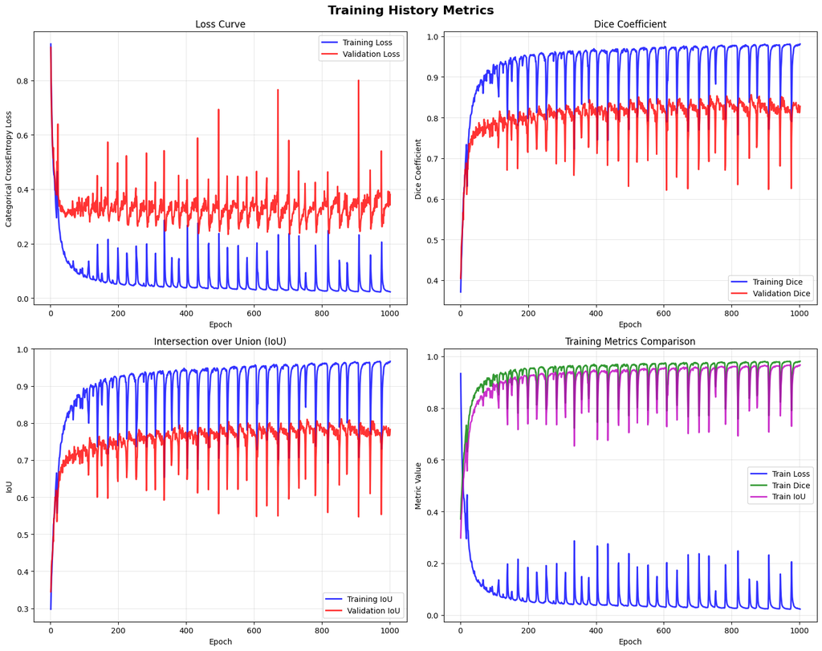

```
Plot saved as training_history.png
```

```python
# Load training and validation logs
try:
    train_epochs, train_loss, train_dice, train_iou = load_log_file('train_logs.txt')
    val_epochs, val_loss, val_dice, val_iou = load_log_file('val_logs.txt')

    # Plot and save the metrics
    plot_metrics(train_epochs, train_loss, train_dice, train_iou,
                val_epochs, val_loss, val_dice, val_iou,
                save_path='training_history.png')

except FileNotFoundError as e:
    print(f"Error: {e}")
    print("Please make sure both 'train_logs.txt' and 'val_logs.txt' exist in the current directory.")
except Exception as e:
    print(f"Error loading files: {e}")
```

### In this function, we go through the image-samples from the test folder and dump them in `test_dumps` folder. We also store the overlays of the predicted masks and the ground-truth masks in the test images and save them. Also returns the list of Dice and IoU metrics to be used later

```python
def test_dump_with_checkpoint(test_loader, checkpoint_path, dump_folder="test_dumps", num_classes=3):
    """
    Load checkpoint and dump test images with predictions and overlays
    """
    # Create dump folder
    Path(dump_folder).mkdir(parents=True, exist_ok=True)

    # Load model and checkpoint
    model = ResUnetPlusPlus(input_ch=3, n_class=num_classes)
    model = model.to(device)

    # Load checkpoint
    checkpoint = torch.load(checkpoint_path, map_location=device)
    model.load_state_dict(checkpoint['state_dict'])

    print(f"Loaded checkpoint from epoch: {checkpoint.get('epoch', 'Unknown')}")

    model.eval()
    progress_bar = tqdm(enumerate(test_loader))

    # Get color map for visualization
    color_map = create_color_map()

    # Store metrics for each image
    image_metrics = []

    with torch.no_grad():
        for step, (inp__, gt__, file_name) in progress_bar:
            inp__ = inp__.to(device)
            gt__ = gt__.to(device)

            # Get predictions
            pred_logits = model.forward(inp__)
            pred_probs = torch.softmax(pred_logits, dim=1)
            pred_classes = torch.argmax(pred_probs, dim=1)

            # Calculate metrics for this batch
            dice_per_class, mean_dice = dice_coefficient(pred_probs, gt__, num_classes)
            iou_per_class, mean_iou = iou_coefficient(pred_probs, gt__, num_classes)

            # Convert to numpy
            p_img = pred_classes.cpu().numpy()
            gt_img = gt__.cpu().numpy()
            inp_img = inp__.cpu().numpy()

            progress_bar.set_description(f"Processing image {step+1} - Dice: {mean_dice.item():.4f}")

            # Save images for each item in batch
            for batch_idx, (p_image_loop, gt_img_loop, inp_img_loop) in enumerate(zip(p_img, gt_img, inp_img)):

                # Store metrics for this image
                current_dice_scores = dice_per_class.cpu().numpy()
                current_iou_scores = iou_per_class.cpu().numpy()

                image_info = {
                    'filename': str(file_name[batch_idx]),
                    'dice_class1': current_dice_scores[1],  # Class 1 dice
                    'dice_class2': current_dice_scores[2],  # Class 2 dice
                    'dice_mean': mean_dice.item(),
                    'iou_class1': current_iou_scores[1],
                    'iou_class2': current_iou_scores[2],
                    'iou_mean': mean_iou.item()
                }
                image_metrics.append(image_info)

                # Prepare input image for overlay
                inp_img_display = np.transpose(inp_img_loop, (1, 2, 0))
                inp_img_display = (inp_img_display * 255.0).astype(np.uint8)

                # Create colored masks
                pred_colored = apply_color_map(p_image_loop, color_map)
                gt_colored = apply_color_map(gt_img_loop, color_map)

                # Create overlays
                pred_overlay = create_overlay(inp_img_display, pred_colored, alpha=0.4)
                gt_overlay = create_overlay(inp_img_display, gt_colored, alpha=0.4)

                # Save all images
                base_name = str(file_name[batch_idx])
                cv2.imwrite(os.path.join(dump_folder, f"{base_name}_input.png"),
                           cv2.cvtColor(inp_img_display, cv2.COLOR_RGB2BGR))
                cv2.imwrite(os.path.join(dump_folder, f"{base_name}_pred_mask.png"),
                           cv2.cvtColor(pred_colored, cv2.COLOR_RGB2BGR))
                cv2.imwrite(os.path.join(dump_folder, f"{base_name}_gt_mask.png"),
                           cv2.cvtColor(gt_colored, cv2.COLOR_RGB2BGR))
                cv2.imwrite(os.path.join(dump_folder, f"{base_name}_pred_overlay.png"),
                           cv2.cvtColor(pred_overlay, cv2.COLOR_RGB2BGR))
                cv2.imwrite(os.path.join(dump_folder, f"{base_name}_gt_overlay.png"),
                           cv2.cvtColor(gt_overlay, cv2.COLOR_RGB2BGR))

                # Create side-by-side comparison
                comparison = np.hstack([inp_img_display, gt_colored, pred_colored, gt_overlay, pred_overlay])
                cv2.imwrite(os.path.join(dump_folder, f"{base_name}_comparison.png"),
                           cv2.cvtColor(comparison, cv2.COLOR_RGB2BGR))

    print(f"\nCompleted test dump. Images saved in: {dump_folder}")
    return image_metrics
```

### This function calculates the mean and standard deviation of predicted masks based on the ground truth masks

```python
def calculate_class_metrics(image_metrics):
    """
    Calculate mean ± std for dice coefficients of class 1 and class 2
    """
    dice_class1 = [img['dice_class1'] for img in image_metrics]
    dice_class2 = [img['dice_class2'] for img in image_metrics]

    # Calculate statistics
    dice_c1_mean = np.mean(dice_class1)
    dice_c1_std = np.std(dice_class1)
    dice_c2_mean = np.mean(dice_class2)
    dice_c2_std = np.std(dice_class2)

    print("\n" + "="*60)
    print("DICE COEFFICIENT RESULTS")
    print("="*60)
    print(f"Class 1 Dice: {dice_c1_mean:.4f} ± {dice_c1_std:.4f}")
    print(f"Class 2 Dice: {dice_c2_mean:.4f} ± {dice_c2_std:.4f}")
    print("="*60)

    # Also calculate overall metrics
    overall_dice = [img['dice_mean'] for img in image_metrics]
    iou_class1 = [img['iou_class1'] for img in image_metrics]
    iou_class2 = [img['iou_class2'] for img in image_metrics]
    overall_iou = [img['iou_mean'] for img in image_metrics]

    print(f"Overall Dice: {np.mean(overall_dice):.4f} ± {np.std(overall_dice):.4f}\n\n")
    print(f"Class 1 IoU: {np.mean(iou_class1):.4f} ± {np.std(iou_class1):.4f}")
    print(f"Class 2 IoU: {np.mean(iou_class2):.4f} ± {np.std(iou_class2):.4f}")
    print(f"Overall IoU: {np.mean(overall_iou):.4f} ± {np.std(overall_iou):.4f}")

    return {
        'dice_class1': {'mean': dice_c1_mean, 'std': dice_c1_std},
        'dice_class2': {'mean': dice_c2_mean, 'std': dice_c2_std},
        'overall_dice': {'mean': np.mean(overall_dice), 'std': np.std(overall_dice)}
    }
```

### This function displays the best performing image-prediction overlays and the worst performing image-prediction overlays based on the prediction of model.

```python
def display_best_worst_images(image_metrics, dump_folder, top_k=5, criterion='dice_mean'):
    """
    Display the best and worst performing images based on specified criterion
    """
    # Sort images by performance
    sorted_metrics = sorted(image_metrics, key=lambda x: x[criterion])

    worst_images = sorted_metrics[:top_k]  # Lowest scores
    best_images = sorted_metrics[-top_k:]  # Highest scores
    best_images.reverse()  # Show best first

    print(f"\n" + "="*80)
    print(f"TOP {top_k} BEST PERFORMING IMAGES (by {criterion})")
    print("="*80)

    fig, axes = plt.subplots(top_k, 5, figsize=(20, 4*top_k))
    if top_k == 1:
        axes = axes.reshape(1, -1)

    for idx, img_info in enumerate(best_images):
        filename = img_info['filename']
        score = img_info[criterion]

        print(f"{idx+1}. {filename} - {criterion}: {score:.4f}")
        print(f"   Class 1 Dice: {img_info['dice_class1']:.4f}, Class 2 Dice: {img_info['dice_class2']:.4f}")

        # Load and display images
        input_img = cv2.imread(os.path.join(dump_folder, f"{filename}_input.png"))
        gt_mask = cv2.imread(os.path.join(dump_folder, f"{filename}_gt_mask.png"))
        pred_mask = cv2.imread(os.path.join(dump_folder, f"{filename}_pred_mask.png"))
        gt_overlay = cv2.imread(os.path.join(dump_folder, f"{filename}_gt_overlay.png"))
        pred_overlay = cv2.imread(os.path.join(dump_folder, f"{filename}_pred_overlay.png"))

        # Convert BGR to RGB for matplotlib
        images = [input_img, gt_mask, pred_mask, gt_overlay, pred_overlay]
        titles = ['Input', 'GT Mask', 'Pred Mask', 'GT Overlay', 'Pred Overlay']

        for j, (img, title) in enumerate(zip(images, titles)):
            if img is not None:
                img_rgb = cv2.cvtColor(img, cv2.COLOR_BGR2RGB)
                axes[idx, j].imshow(img_rgb)
                axes[idx, j].set_title(f'{title}\n{criterion}: {score:.3f}')
                axes[idx, j].axis('off')

    plt.suptitle(f'Best {top_k} Images by {criterion}', fontsize=16, y=0.98)
    plt.tight_layout()
    plt.show()

    print(f"\n" + "="*80)
    print(f"TOP {top_k} WORST PERFORMING IMAGES (by {criterion})")
    print("="*80)

    fig, axes = plt.subplots(top_k, 5, figsize=(20, 4*top_k))
    if top_k == 1:
        axes = axes.reshape(1, -1)

    for idx, img_info in enumerate(worst_images):
        filename = img_info['filename']
        score = img_info[criterion]

        print(f"{idx+1}. {filename} - {criterion}: {score:.4f}")
        print(f"   Class 1 Dice: {img_info['dice_class1']:.4f}, Class 2 Dice: {img_info['dice_class2']:.4f}")

        # Load and display images
        input_img = cv2.imread(os.path.join(dump_folder, f"{filename}_input.png"))
        gt_mask = cv2.imread(os.path.join(dump_folder, f"{filename}_gt_mask.png"))
        pred_mask = cv2.imread(os.path.join(dump_folder, f"{filename}_pred_mask.png"))
        gt_overlay = cv2.imread(os.path.join(dump_folder, f"{filename}_gt_overlay.png"))
        pred_overlay = cv2.imread(os.path.join(dump_folder, f"{filename}_pred_overlay.png"))

        # Convert BGR to RGB for matplotlib
        images = [input_img, gt_mask, pred_mask, gt_overlay, pred_overlay]
        titles = ['Input', 'GT Mask', 'Pred Mask', 'GT Overlay', 'Pred Overlay']

        for j, (img, title) in enumerate(zip(images, titles)):
            if img is not None:
                img_rgb = cv2.cvtColor(img, cv2.COLOR_BGR2RGB)
                axes[idx, j].imshow(img_rgb)
                axes[idx, j].set_title(f'{title}\n{criterion}: {score:.3f}')
                axes[idx, j].axis('off')

    plt.suptitle(f'Worst {top_k} Images by {criterion}', fontsize=16, y=0.98)
    plt.tight_layout()
    plt.show()
```

### Shows the class wise and overall Dice and IoU of the predicted masks

```python
# Parameters - load from the saved checkpoint and mention the dump folder name
checkpoint_path = "multiclass_model_998.pt"
dump_folder = "test_dumps"
num_classes = 3

# Get test image addresses
test_image_address_list = get_image_address("./", "test_images")
print(f"Total Number of Test Images: {len(test_image_address_list)}")

# Create test loader
test_loader = load_data(
    test_image_address_list, masks_folder="test_masks", batch_size=1,
    num_workers=8, shuffle=False, num_classes=num_classes)

# Run test dump
print("Starting test dump with checkpoint loading...")
image_metrics = test_dump_with_checkpoint(
    test_loader, checkpoint_path, dump_folder, num_classes)

# Calculate and display metrics
print("Calculating class-wise metrics...")
metrics_summary = calculate_class_metrics(image_metrics)
```

```
Number of Files not found :  0
Total Number of Files found :  2362
Total Number of Test Images: 2362
Starting test dump with checkpoint loading...
Loaded checkpoint from epoch: 1000
```

```
Processing image 2362 - Dice: 0.7259: : 2362it [02:44, 14.38it/s]
```

```
Completed test dump. Images saved in: test_dumps
Calculating class-wise metrics...

============================================================
DICE COEFFICIENT RESULTS
============================================================
Class 1 Dice: 0.8544 ± 0.2623
Class 2 Dice: 0.9306 ± 0.2090
============================================================
Overall Dice: 0.9227 ± 0.1426


Class 1 IoU: 0.8077 ± 0.2738
Class 2 IoU: 0.9136 ± 0.2248
Overall IoU: 0.8964 ± 0.1586
```

```
Displaying best and worst performing images...

================================================================================
TOP 3 BEST PERFORMING IMAGES (by dice_mean)
================================================================================
1. 0129_5 - dice_mean: 0.9991
   Class 1 Dice: 1.0000, Class 2 Dice: 0.9983
2. 0654_1 - dice_mean: 0.9989
   Class 1 Dice: 1.0000, Class 2 Dice: 0.9987
3. 0573_0 - dice_mean: 0.9988
   Class 1 Dice: 1.0000, Class 2 Dice: 0.9977
```

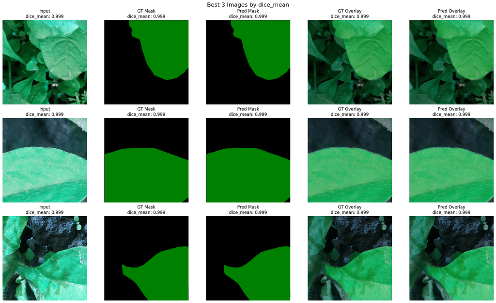

```
================================================================================
TOP 3 WORST PERFORMING IMAGES (by dice_mean)
================================================================================
1. 0136_5 - dice_mean: 0.2355
   Class 1 Dice: 0.0000, Class 2 Dice: 0.0500
2. 0136_3 - dice_mean: 0.2536
   Class 1 Dice: 0.0000, Class 2 Dice: 0.0734
3. 0136_2 - dice_mean: 0.2782
   Class 1 Dice: 0.0000, Class 2 Dice: 0.1701
```

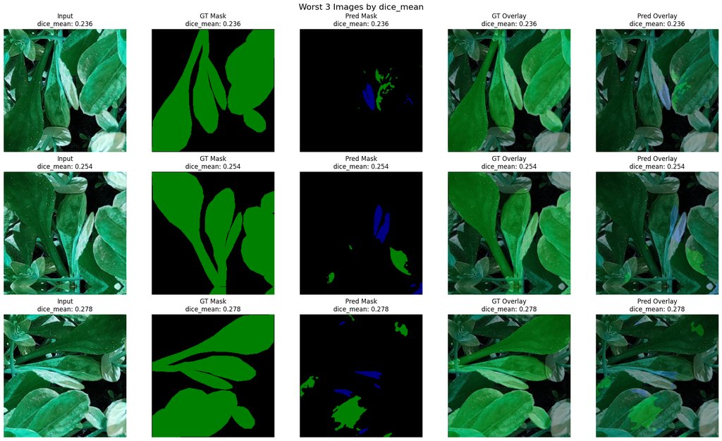

```python
# Display best and worst images
print("Displaying best and worst performing images...")
display_best_worst_images(image_metrics, dump_folder, top_k=3, criterion='dice_mean')
```

```
Displaying based on Class 1 Dice performance...

================================================================================
TOP 3 BEST PERFORMING IMAGES (by dice_class1)
================================================================================
1. 0347_1 - dice_class1: 1.0000
   Class 1 Dice: 1.0000, Class 2 Dice: 0.9886
2. 0577_5 - dice_class1: 1.0000
   Class 1 Dice: 1.0000, Class 2 Dice: 0.9909
3. 0283_4 - dice_class1: 1.0000
   Class 1 Dice: 1.0000, Class 2 Dice: 0.9908
```

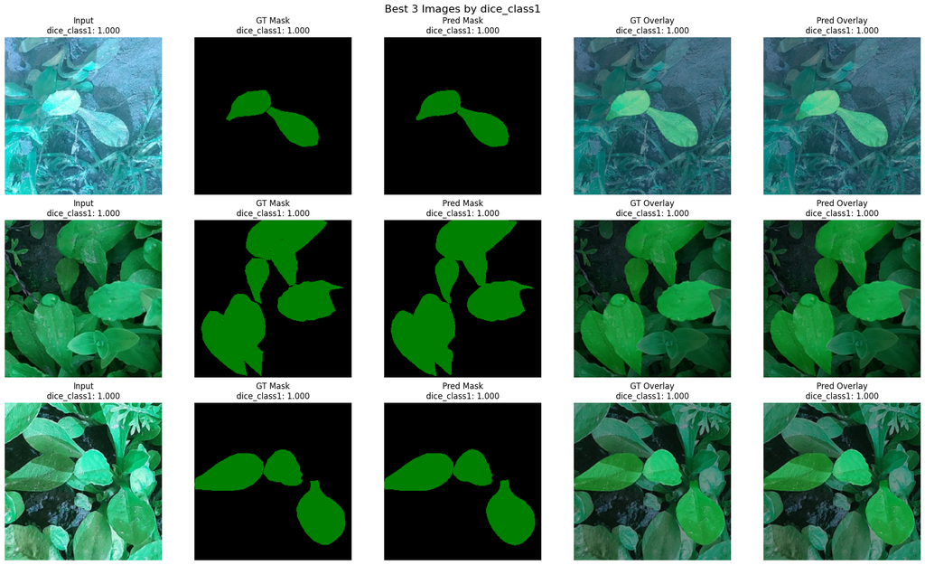

```
================================================================================
TOP 3 WORST PERFORMING IMAGES (by dice_class1)
================================================================================
1. 0394_4 - dice_class1: 0.0000
   Class 1 Dice: 0.0000, Class 2 Dice: 0.7643
2. 0024_5 - dice_class1: 0.0000
   Class 1 Dice: 0.0000, Class 2 Dice: 0.8337
3. 0653_4 - dice_class1: 0.0000
   Class 1 Dice: 0.0000, Class 2 Dice: 0.9222
```

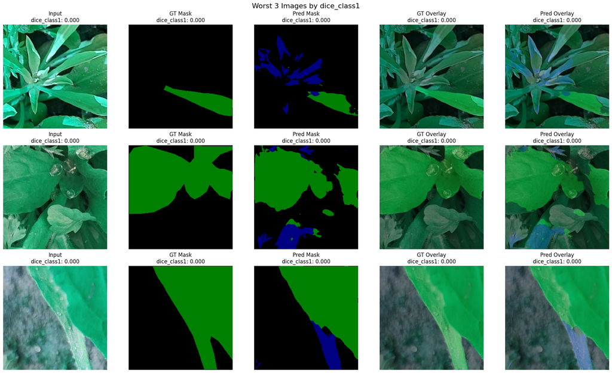

```python
# display based on specific class performance
print("\nDisplaying based on Class 1 Dice performance...")
display_best_worst_images(image_metrics, dump_folder, top_k=3, criterion='dice_class1')
```

```
Displaying based on Class 2 Dice performance...

================================================================================
TOP 3 BEST PERFORMING IMAGES (by dice_class2)
================================================================================
1. 0202_5 - dice_class2: 1.0000
   Class 1 Dice: 0.9678, Class 2 Dice: 1.0000
2. 0173_4 - dice_class2: 1.0000
   Class 1 Dice: 0.9186, Class 2 Dice: 1.0000
3. 0775_1 - dice_class2: 1.0000
   Class 1 Dice: 0.9272, Class 2 Dice: 1.0000
```

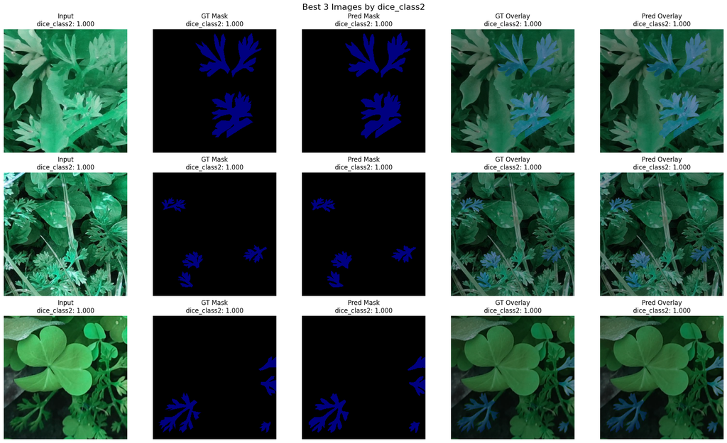

```
================================================================================
TOP 3 WORST PERFORMING IMAGES (by dice_class2)
================================================================================
1. 0424_2 - dice_class2: 0.0000
   Class 1 Dice: 0.4869, Class 2 Dice: 0.0000
2. 0061_5 - dice_class2: 0.0000
   Class 1 Dice: 1.0000, Class 2 Dice: 0.0000
3. 0221_5 - dice_class2: 0.0000
   Class 1 Dice: 0.3215, Class 2 Dice: 0.0000
```

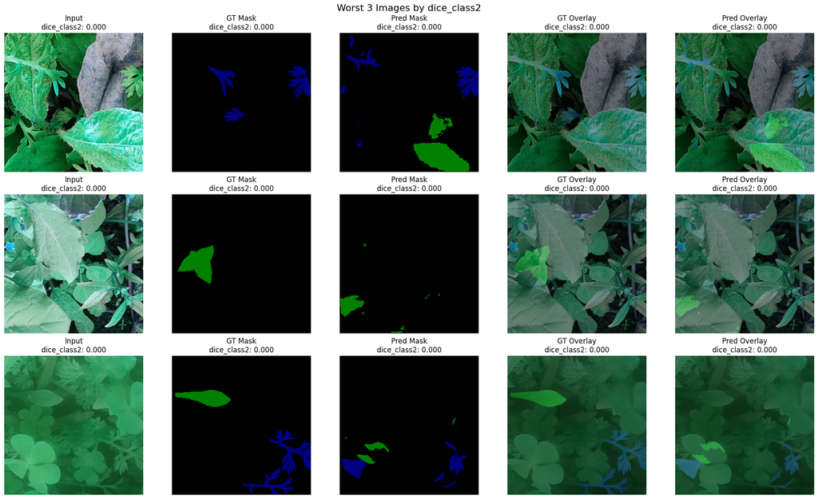

```python
print("\nDisplaying based on Class 2 Dice performance...")
display_best_worst_images(image_metrics, dump_folder, top_k=3, criterion='dice_class2')
```

```python
def visualize_conv_kernels(model, layer_name, save_folder="kernel_patterns"):
    """
    Visualize and save convolutional kernel patterns from a specific layer
    """
    Path(save_folder).mkdir(parents=True, exist_ok=True)

    # Get the layer by name
    layer = dict(model.named_modules())[layer_name]

    if not isinstance(layer, (torch.nn.Conv2d, torch.nn.ConvTranspose2d)):
        print(f"Layer {layer_name} is not a convolutional layer")
        return

    # Get kernel weights [out_channels, in_channels, kernel_h, kernel_w]
    kernels = layer.weight.data.cpu().numpy()

    print(f"Layer: {layer_name}")
    print(f"Kernel shape: {kernels.shape}")

    # Number of output channels (filters)
    num_filters = kernels.shape[0]
    num_input_channels = kernels.shape[1]

    # Create subplots - show first 64 filters max
    max_filters = min(64, num_filters)
    cols = 8
    rows = (max_filters + cols - 1) // cols

    fig, axes = plt.subplots(rows, cols, figsize=(16, 2*rows))
    if rows == 1:
        axes = axes.reshape(1, -1)

    for i in range(max_filters):
        row = i // cols
        col = i % cols

        # For multi-channel input, take mean across input channels
        if num_input_channels > 1:
            kernel_img = np.mean(kernels[i], axis=0)
        else:
            kernel_img = kernels[i, 0]

        # Normalize to [0, 1] for visualization
        kernel_img = (kernel_img - kernel_img.min()) / (kernel_img.max() - kernel_img.min() + 1e-8)

        axes[row, col].imshow(kernel_img, cmap='viridis', interpolation='nearest')
        axes[row, col].set_title(f'Filter {i}', fontsize=8)
        axes[row, col].axis('off')

    # Hide unused subplots
    for i in range(max_filters, rows * cols):
        row = i // cols
        col = i % cols
        axes[row, col].axis('off')

    plt.suptitle(f'Kernels from {layer_name}', fontsize=14)
    plt.tight_layout()
    plt.savefig(f'{save_folder}/{layer_name.replace(".", "_")}_kernels.png', dpi=300, bbox_inches='tight')
    plt.show()

    return kernels


def visualize_feature_maps(model, input_tensor, layer_name, save_folder="feature_maps"):
    """
    Visualize feature maps from a specific layer given an input
    """
    Path(save_folder).mkdir(parents=True, exist_ok=True)

    # Hook to capture feature maps
    feature_maps = {}

    def hook_fn(module, input, output):
        feature_maps[layer_name] = output.detach()

    # Register hook
    layer = dict(model.named_modules())[layer_name]
    handle = layer.register_forward_hook(hook_fn)

    # Forward pass
    model.eval()
    with torch.no_grad():
        _ = model(input_tensor)

    # Remove hook
    handle.remove()

    # Get feature maps
    fmaps = feature_maps[layer_name].cpu().numpy()

    print(f"Feature maps shape: {fmaps.shape}")  # [batch, channels, height, width]

    # Take first sample from batch
    fmaps = fmaps[0]  # [channels, height, width]

    # Show first 64 feature maps
    max_maps = min(64, fmaps.shape[0])
    cols = 8
    rows = (max_maps + cols - 1) // cols

    fig, axes = plt.subplots(rows, cols, figsize=(16, 2*rows))
    if rows == 1:
        axes = axes.reshape(1, -1)

    for i in range(max_maps):
        row = i // cols
        col = i % cols

        fmap = fmaps[i]
        axes[row, col].imshow(fmap, cmap='viridis')
        axes[row, col].set_title(f'Channel {i}', fontsize=8)
        axes[row, col].axis('off')

    # Hide unused subplots
    for i in range(max_maps, rows * cols):
        row = i // cols
        col = i % cols
        axes[row, col].axis('off')

    plt.suptitle(f'Feature Maps from {layer_name}', fontsize=14)
    plt.tight_layout()
    plt.savefig(f'{save_folder}/{layer_name.replace(".", "_")}_fmaps.png', dpi=300, bbox_inches='tight')
    plt.show()

    return fmaps


def analyze_model_patterns(checkpoint_path, sample_input=None):
    """
    Main function to analyze kernel patterns and feature maps
    """
    # Load model
    model = ResUnetPlusPlus(input_ch=3, n_class=3)
    checkpoint = torch.load(checkpoint_path, map_location=device)
    model.load_state_dict(checkpoint['state_dict'])
    model.to(device)
    model.eval()

    # Print all layer names to help identify layers of interest
    print("Available layers:")
    for name, module in model.named_modules():
        if isinstance(module, (torch.nn.Conv2d, torch.nn.ConvTranspose2d)):
            print(f"  {name}: {type(module).__name__} {module.weight.shape}")

    # Create sample input if not provided
    if sample_input is None:
        sample_input = torch.randn(1, 3, 256, 256).to(device)

    # Analyze different layers - modify these based on your model architecture
    layers_to_analyze = [
        # First layer (typically captures edges/basic patterns)
        "encoder.0",  # or whatever your first conv layer is named

        # Middle layers (intermediate features)
        "encoder.4",  # adjust based on your model

        # Final layers (high-level features)
        "decoder.0",  # adjust based on your model
        "final_conv",  # or your final output layer
    ]

    # You may need to adjust layer names based on your actual model structure
    # Uncomment and modify the layer names that exist in your model:

    # Example for common layer names:
    # layers_to_analyze = [
    #     "conv1",
    #     "layer1.0.conv1",
    #     "layer2.0.conv1",
    #     "layer3.0.conv1",
    #     "layer4.0.conv1",
    #     "classifier"  # final layer
    # ]

    print("\nAnalyzing kernel patterns...")
    for layer_name in layers_to_analyze:
        try:
            print(f"\n--- Analyzing {layer_name} ---")

            # Visualize kernels
            kernels = visualize_conv_kernels(model, layer_name)

            # Visualize feature maps
            feature_maps = visualize_feature_maps(model, sample_input, layer_name)

        except KeyError:
            print(f"Layer '{layer_name}' not found in model. Skipping...")
            continue
        except Exception as e:
            print(f"Error analyzing layer '{layer_name}': {e}")
            continue
```